# Chapter 11: Univariate Regression

# Class One Start

### Scene 1

**Prompt:** Explore the county level data from [here](https://www.ers.usda.gov/data-products/county-level-data-sets/download-data/) with your partner and try to figure out the variables mean. Can you find any “interesting” observations? Which variables are worth looking at? `poverty` is the percentage of the county living in poverty is 2018. `less_than_hs` is the percentage of the county without at least a high school diploma. `hs` is the percent of the county who have a high school degree, but no further education.

```
## Observations: 3,129
## Variables: 6
## $ region       <chr> "South", "South", "South", "South", "South", "South", "S…
## $ state        <chr> "AL", "AL", "AL", "AL", "AL", "AL", "AL", "AL", "AL", "A…
## $ name         <chr> "Autauga County", "Baldwin County", "Barbour County", "B…
## $ poverty      <dbl> 13.8, 9.8, 30.9, 21.8, 13.2, 42.5, 24.5, 19.5, 18.7, 16.…
## $ less_than_hs <dbl> 11.3, 9.7, 27.0, 16.8, 19.8, 24.8, 15.4, 15.9, 18.6, 19.…
## $ hs           <dbl> 32.6, 27.6, 35.7, 47.3, 34.0, 39.7, 43.9, 32.4, 38.4, 38…
```

```
## # A tibble: 10 x 6
##    region    state name                     poverty less_than_hs    hs
##    <chr>     <chr> <chr>                      <dbl>        <dbl> <dbl>
##  1 Northeast PA    Lebanon County              10           13    44.2
##  2 Midwest   MN    Dodge County                 6.1          5.2  34.7
##  3 Midwest   MN    Lake of the Woods County    10.4          8.4  39
##  4 Midwest   NE    Kearney County               9.2          3.9  34.2
##  5 South     TX    Carson County                8.9          6.4  28.8
##  6 West      AK    Aleutians East Borough      15.5         13.6  40.2
##  7 South     VA    Franklin city               18.3         17.2  30.6
##  8 Northeast NY    Westchester County           8.3         12.2  19.6
##  9 Midwest   MO    Holt County                 13.3          9.1  43.9
## 10 Midwest   WI    Taylor County               10.3         11.4  45.1
```

```
##     region             state               name              poverty
##  Length:3129        Length:3129        Length:3129        Min.   : 2.60
##  Class :character   Class :character   Class :character   1st Qu.:10.80
##  Mode  :character   Mode  :character   Mode  :character   Median :14.10
##                                                           Mean   :15.17
##                                                           3rd Qu.:18.30
##                                                           Max.   :54.00
##   less_than_hs         hs
##  Min.   : 1.20   Min.   : 5.5
##  1st Qu.: 8.80   1st Qu.:29.8
##  Median :12.10   Median :34.6
##  Mean   :13.42   Mean   :34.3
##  3rd Qu.:17.20   3rd Qu.:39.3
##  Max.   :66.30   Max.   :55.6
```

```
## # A tibble: 3,129 x 3
##    name            poverty    hs
##    <chr>             <dbl> <dbl>
##  1 Autauga County     13.8  32.6
##  2 Baldwin County      9.8  27.6
##  3 Barbour County     30.9  35.7
##  4 Bibb County        21.8  47.3
##  5 Blount County      13.2  34
##  6 Bullock County     42.5  39.7
##  7 Butler County      24.5  43.9
##  8 Calhoun County     19.5  32.4
##  9 Chambers County    18.7  38.4
## 10 Cherokee County    16.3  38.3
## # … with 3,119 more rows
```

# Scene 2

**Prompt** Let’s start by exploring our numerical outcome variable `poverty` and our numerical explanatory variable `less_than_hs`. What is the average poverty rate in the US? How does this compare with that of your county (if not from US look up Middlesex County - the county that Cambridge, MA is in)? Furthermore, what is the average percentage of adults without and with a high school diploma? Which state’s county has the highest percentage of adults without a high school diploma?

```
## # A tibble: 1 x 1
##   avgPovery
##       <dbl>
## 1      15.2
```

```
## [1] 15.3
```

```
## # A tibble: 1 x 2
##   without_hs with_hs
##        <dbl>   <dbl>
## 1       13.4    34.3
```

```
## # A tibble: 3,129 x 3
##    state name            less_than_hs
##    <chr> <chr>                  <dbl>
##  1 TX    Kenedy County           66.3
##  2 TX    Starr County            48.5
##  3 TX    Presidio County         47.6
##  4 TX    Hudspeth County         46.1
##  5 OH    Holmes County           42.4
##  6 TX    Maverick County         40.3
##  7 TX    Zapata County           40
##  8 ID    Clark County            39.2
##  9 TX    Gaines County           38.8
## 10 TX    Garza County            38.6
## # … with 3,119 more rows
```

# Scene 3

**Prompt** What is the correlation coefficient of `poverty` and `less_than_hs`? What does it mean?

```
## # A tibble: 1 x 1
##   correlation
##         <dbl>
## 1       0.658
```

# Scene 3a:

**Prompt** Assume we are trying to understand the causes of poverty. Chapter 11 discusses two types of models: explanatory and predictive. Which kind is this? Is this a causal relationship? Discuss this in the context of the Rubin Causal Model and potential outcomes.

==> EXPLANATORY

note: models do not exist independent of someone’s motivations

alt prompt: given the rate of less_than_hs for an county, what is the likely poverty rate? ==> PREDICTIVE

# Scene 3B

**Prompt** Assume we want to create an explanatory model. Create a new variable, `good_education`, which is 1 if `less_than_hs`is less than 13 and 0 if it is not. Discuss this in the context of the Rubin Causal Model and potential outcomes. Write down the units, the treatments, and the outcomes. Define the causal effect of `good_education` on poverty rate.

```
## # A tibble: 1 x 1
##   correlation
##         <dbl>
## 1      -0.791
```

# Scene 4

**Prompt** Use a scatterplot to visualize this data, including a straight line of best fit.

```
##
## Call:
## lm(formula = poverty ~ less_than_hs, data = county)
##
## Coefficients:
##  (Intercept)  less_than_hs
##       6.6351        0.6366
```

```
##
## Call:
## lm(formula = poverty ~ less_than_hs_2, data = revised)
##
## Coefficients:
##    (Intercept)  less_than_hs_2
##          6.635          63.655
```

```
## # A tibble: 1 x 1
##   correlation
##         <dbl>
## 1       0.658
```

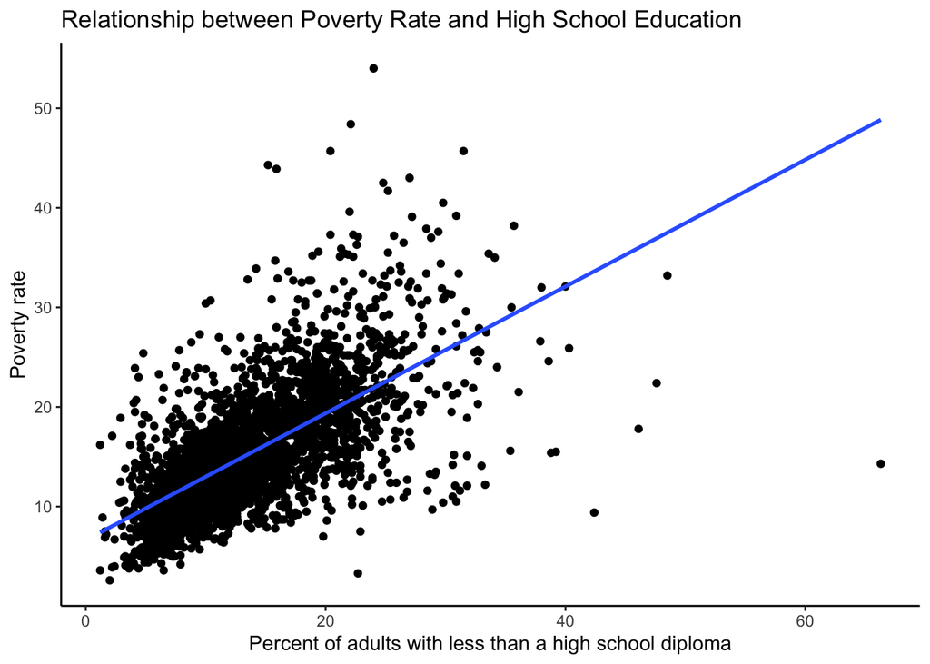

# Scene 5

**Prompt** Create an animation of the scatterplot above with the percent of adults with less than a high school diploma on the x axis and the poverty rate in the y axis. This scatterplot should transition through the four US regions. Hint: classify the ‘county’ data into the 4 US regions. Then create an animation of a scatterplot that transitions through each region. Hint: Read the [Animation appendix](https://davidkane9.github.io/PPBDS/C-animation.html) of the *[Primer](https://davidkane9.github.io/PPBDS/)*. You only need to add one command to the basic static `ggplot()` call.

```
## nframes and fps adjusted to match transition
```

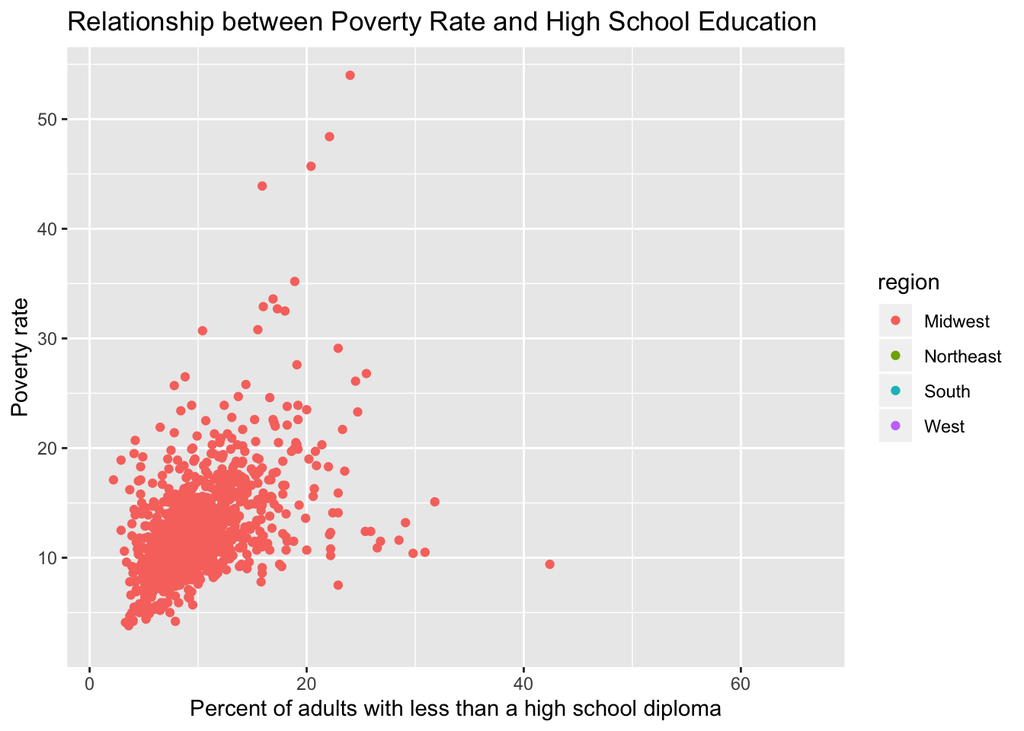

# Scene 6

**Prompt** Using the `lm()` function, fit a model with this data in which `poverty` is the dependent variable and `less_than_hs` is the independent variable. Save the resulting object as `poverty_model`. Then, use the tidy() function found in section 11.1.2 to obtain the regression parameters. You should have a 2x7 regression table with terms of (Intercept) and `less_than_hs`, as well as an estimate, std.error, statistic, p.value, conf.low, and conf.high. Write one sentence explaining what the intercept means and one sentence about what the slope means.

# Scene 7

**Prompt** Use nest() to create a bootstrap sample of the linear regression. In this dataset, we’ll have a resampled collection of counties in which we’ll sometimes have multiple counties represented and sometimes there won’t be any from our original ‘county’ data.

# Scene 8

**Prompt** Now, using the starter code above, go ahead and add more columns. Make one called `mod` which will contains the model objects created by `lm()`. Then, add one called `reg_results` which will tidy the objects created by `lm()`, and then one called `disp_coef` which will display the regression coefficient for each bootstrap sample.

# Scene 9

**Prompt** Create a confidence interval of the slope of our linear regression. What is the value at the 50th percentile? Is that expected? Provide a Bayesian and Frequentist interpretation of this interval.

# Scene 10

**Prompt** Now, let’s use a shortcut. Use the confidence intervals reported by `lm()` and `tidy()`.

# Scene 11

**Prompt** Alas, our data is missing Travis County in Texas. Suppose Travis County has 10.9% of adults with less than a high school degree. What do you think its poverty rate would be? Why?

# Scene 12

**Prompt** Suppose I tell you now that Travis County has a 12% poverty rate. By how much was your estimate off? Why?

# Scene 13

**Prompt** Now, compute the fitted and residual values for each county. Explain what the following columns mean in one sentence each: poverty, pct_less_hs, .fitted, .resid. What does it mean to have a positive residual?

# Scene 14

**Prompt** Find the largest positive residual and largest negative residual. Why do you think there is such a large discrepancy?

# Scene 15

**Prompt** Go back and read the first part of Chapter 11 in the *Primer*. Are we modeling for explanation or for prediction? How do you know?

# Scene 1

**Prompt** Find the standard error of the fitted values, and then construct a confidence interval. Remember, a 95% confidence interval can be found by adding/subtracting 1.96 * SE to the mean. Why is the uncertainty for particular predictions higher than the uncertainty for our estimate of the coefficient on less_than_hs?

# Scene 2